# An Analysis of the Damage Caused by Natural Events

Raymond Dineen

8/19/2020

### Synopsis

The data for this analysis comes from the U.S. National Oceanic and Atmospheric Administration’s (NOAA) storm database. It contains data from every recorded storm/natural event starting from 1950. For out purposes, we only look at the data starting from 1996 since that is when all 48 official event types started being recorded. The data requires a bit of cleaning due to the considerable amount of typos and non-standard entries in the event type column. This is a potential source of errors since there are some many personal judgment calls to make about how to group classify the non-standard entries, if we even choose to use them in our analysis. After the cleaning, we graph the data into bar plots that answer questions about the impact these storms have on human health as well as property and crop damage. We look at it from a per-event and overall perspective to see which events are most devastating when they occur and which events are the greatest overall threats.

### Data Processing

The data comes in .csv format that is compressed using the bzip2 algorithm. It can be read into R by simply using read.csv(), as shown below.

```r
URL <- "https://d396qusza40orc.cloudfront.net/repdata%2Fdata%2FStormData.csv.bz2"
download.file(URL, destfile = "./StormData.csv.bz2")
stormData <- read.csv("StormData.csv.bz2")
```

This data set contains data from 1950 to 2011. According to [NOAA](https://www.ncdc.noaa.gov/stormevents/details.jsp?type=eventtype), the recording of all 48 different event types didn’t start until January 1996. Because of this, we will filter out everything before that point. This also will help account for technological improvements to storm preparation and make the finding more relevant to the present day.

```r
stormData$BGN_DATE <- as.Date(stormData$BGN_DATE, "%m/%d/%Y")
after1996 <- subset(stormData, BGN_DATE >= "1996-01-01")
```

It is important for us to clean up the columns describing the cost of property and crop damage. The value is broken into a number and a multiplier such as “K”, “M”, “B”, referring to thousands, millions, or billions. We will create columns with a singular numeric values for this data. There is also one entry with a “0” multiplier which we can ignore since the reported damage is also 0.

```r
#clean property damage
after1996$PROPDMG[after1996$PROPDMGEXP == "K"] <- after1996$PROPDMG[after1996$PROPDMGEXP == "K"]*10^3
after1996$PROPDMG[after1996$PROPDMGEXP == "M"] <- after1996$PROPDMG[after1996$PROPDMGEXP == "M"]*10^6
after1996$PROPDMG[after1996$PROPDMGEXP == "B"] <- after1996$PROPDMG[after1996$PROPDMGEXP == "B"]*10^9
#repeat for crop damage
after1996$CROPDMG[after1996$CROPDMGEXP == "K"] <- after1996$CROPDMG[after1996$CROPDMGEXP == "K"]*10^3
after1996$CROPDMG[after1996$CROPDMGEXP == "M"] <- after1996$CROPDMG[after1996$CROPDMGEXP == "M"]*10^6
after1996$CROPDMG[after1996$CROPDMGEXP == "B"] <- after1996$CROPDMG[after1996$CROPDMGEXP == "B"]*10^9
```

The other important column to clean up is the EVTYPE column. There official 48 event types are listed in section 2.1.1 of the [Storm Data Documentation](https://d396qusza40orc.cloudfront.net/repdata%2Fpeer2_doc%2Fpd01016005curr.pdf). However, there are currently far more than 48 event types in the data set as we can see from using unique() on the EVTYPE column.

```r
length(unique(after1996$EVTYPE))
```

```
## [1] 516
```

This is the result of typos and slightly different terms often being used than the official list of event types. We can start by standardizing the capitalization on the data and then looking at a table to list the events by frequency.

```r
#make EVTYPE all caps
after1996$EVTYPE <- toupper(after1996$EVTYPE)
#make a table
head(sort(table(after1996$EVTYPE), decreasing = TRUE), 18)
```

```
##
##                     HAIL                TSTM WIND        THUNDERSTORM WIND
##                   207715                   128664                    81403
##              FLASH FLOOD                    FLOOD                  TORNADO
##                    50999                    24248                    23154
##                HIGH WIND               HEAVY SNOW                LIGHTNING
##                    19909                    14000                    13203
##               HEAVY RAIN             WINTER STORM           WINTER WEATHER
##                    11528                    11317                     6987
##         MARINE TSTM WIND             FUNNEL CLOUD MARINE THUNDERSTORM WIND
##                     6175                     6063                     5812
##              STRONG WIND     URBAN/SML STREAM FLD               WATERSPOUT
##                     3564                     3392                     3390
```

We notice right away that two of the most frequent events, TSTM WIND and THUNDERSTORM WIND, are actually the same event listed two ways. We also see URBAN/SML STREAM FLD listed separately from FLASH FLOOD. We can fix these as well as use a few more techniques to group as many of the common typos into their proper groups as we can. The plan is to ignore most of the very infrequent event types that don’t get picked up as they are relatively insignificant in the context of 650000+ events.

```r
library(stringr)
#fix TSTM WIND and MARINE THUNDERSTORM WIND
after1996$EVTYPE <- str_replace_all(after1996$EVTYPE, "^TSTM WIND$", "THUNDERSTORM WIND")
after1996$EVTYPE <- str_replace_all(after1996$EVTYPE, "^MARINE THUNDERSTORM WIND$", "MARINE TSTM WIND")
#fix URBAN/SML STREAM FLD
after1996$EVTYPE <- str_replace_all(after1996$EVTYPE, "^URBAN/SML STREAM FLD$", "FLASH FLOOD")
#fix WILD/FOREST FIRE
after1996$EVTYPE <- str_replace_all(after1996$EVTYPE, "^WILD/FOREST FIRE$", "WILDFIRE")
#group all WINTER WEATHER+ into WINTER WEATHER
after1996$EVTYPE[str_detect(after1996$EVTYPE, "WINTER WEATHER|WINTRY")] <- "WINTER WEATHER"
#group all HOT+ and WARM+ into HEAT
after1996$EVTYPE[str_detect(after1996$EVTYPE, "HOT|WARM")] <- "HEAT"
#TSTM WIND/HAIL to HAIL
after1996$EVTYPE[str_detect(after1996$EVTYPE, "TSTM WIND/HAIL")] <- "HAIL"
#all instances of SURF to HIGH SURF
after1996$EVTYPE[str_detect(after1996$EVTYPE, "SURF")] <- "HIGH SURF"
#all instances of EXTREME COLD to EXTREME COLD/WIND CHILL
after1996$EVTYPE[str_detect(after1996$EVTYPE, "EXTREME COLD")] <- "EXTREME COLD/WIND CHILL"
#SNOW to HEAVY SNOW, WIND to HIGH WIND
after1996$EVTYPE <- str_replace_all(after1996$EVTYPE, "^SNOW$", "HEAVY SNOW")
after1996$EVTYPE <- str_replace_all(after1996$EVTYPE, "^WIND$", "HIGH WIND")
#all instances of HURRICANE or TYPHOON to HURRICANE/TYPHOON
after1996$EVTYPE[str_detect(after1996$EVTYPE, "HURRICANE|TYPHOON")] <- "HURRICANE/TYPHOON"
#all instances of SLEET or FREEZING RAIN to SLEET
after1996$EVTYPE[str_detect(after1996$EVTYPE, "SLEET|FREEZING RAIN")] <- "SLEET"
```

After this cleaning, 99.5% of the recorded events now fall within the top 40 most frequent EVTYPES with at least 200 occurrences. We will pay attention to mostly just those moving forward into the analysis.

```r
library(dplyr)
top40names <- names(sort(table(after1996$EVTYPE), decreasing = TRUE))[1:40]
top40 <- after1996 %>% filter(EVTYPE %in% top40names)
```

### Results

##### Which events were most harmful with respect to population health?

We can answer this question by considering which events caused the most deaths and injuries on average when they occurred as well as total deaths and injuries across the entire time span of the data, 1996-2011.

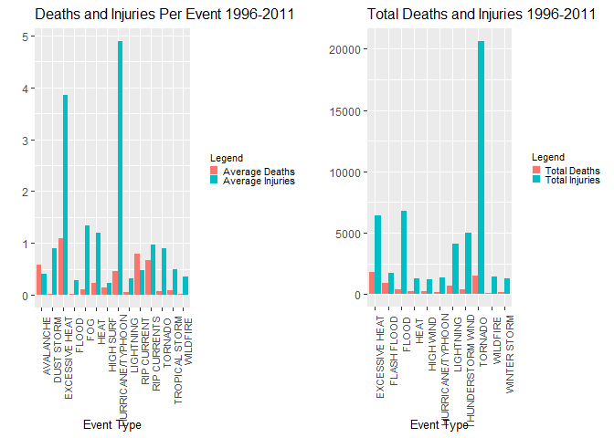

```r
library(tidyr)
library(ggpubr)
#Most Dangerous to health per event
mean_per_event <- top40 %>% mutate(EVTYPE = as.factor(EVTYPE)) %>%
    group_by(EVTYPE) %>%
    summarize(meanfatal = mean(FATALITIES), meaninjur = mean(INJURIES)) %>%
    filter(meanfatal > 0.2 | meaninjur > 0.2) %>%
    gather(key = "stat", value = "value", -EVTYPE) %>%
    ggplot(aes(EVTYPE, value, fill = stat)) +
    geom_col(position = "dodge") +
    theme(axis.text.x = element_text(angle = 90, hjust = 0.95, size = 8),
          legend.text = element_text(size = 8), legend.title = element_text(size = 8),
          title = element_text(size = 10), legend.key.size = unit(0.5, "lines")) +
    scale_fill_discrete(labels = c("Average Deaths", "Average Injuries")) +
    labs(x = "Event Type", y = "", title = "Deaths and Injuries Per Event 1996-2011", fill = "Legend")

#Most dangerous to health sums over the whole data set
sums <- top40 %>% mutate(EVTYPE = as.factor(EVTYPE)) %>%
    group_by(EVTYPE) %>%
    summarize(sumfatal = sum(FATALITIES), suminjur = sum(INJURIES)) %>%
    filter(sumfatal > 1000 | suminjur > 1000) %>%
    gather(key = "stat", value = "value", -EVTYPE) %>%
    ggplot(aes(EVTYPE, value, fill = stat)) +
    geom_col(position = "dodge") +
    theme(axis.text.x = element_text(angle = 90, hjust = 0.95, size = 8),
          legend.text = element_text(size = 8), legend.title = element_text(size = 8),
          title = element_text(size = 10), legend.key.size = unit(0.5, "lines")) +
    scale_fill_discrete(labels = c("Total Deaths", "Total Injuries")) +
    labs(x = "Event Type", y = "", title = "Total Deaths and Injuries 1996-2011", fill = "Legend")

ggarrange(mean_per_event, sums, ncol = 2, nrow = 1)
```

We can see from these graphs that hurricanes and excessive heat cause, by far, the most injuries per event with excessive heat causing the most deaths per event. However, we can also see that tornadoes have caused far more total injuries than any other event with excessive heat, floods, lightning, and thunderstorm wind also posting relatively high total injuries. This is because the frequency of these events occurring is so high that even though on average they may not be as devastating as a hurricane, the damage still adds up to be much higher overall.

##### Which events have the greatest economic consequences?

We answer this question similarly to how we answered the previous question. We will look at damage to property and crops per event as well as overall.

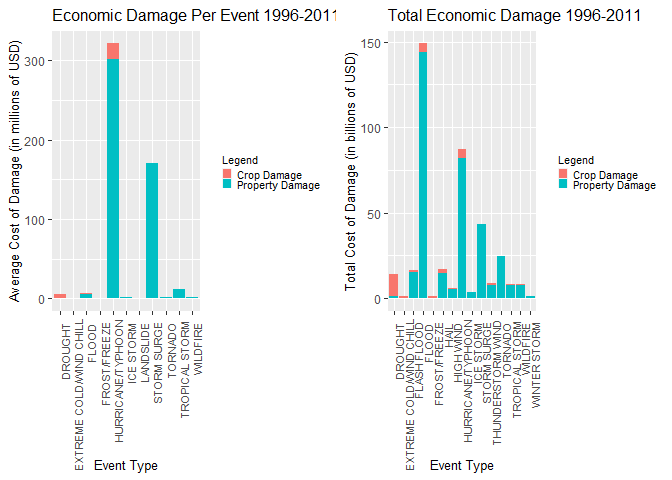

```r
#Economic Damage per event
damage_per_event <- top40 %>% mutate(EVTYPE = as.factor(EVTYPE)) %>%
    group_by(EVTYPE) %>%
    summarize(meancrop = mean(CROPDMG), meanprop = mean(PROPDMG)) %>%
    filter(meancrop > 500000 | meanprop > 500000) %>%
    ungroup() %>%
    gather("stat", "value", -EVTYPE) %>%
    ggplot(aes(EVTYPE, value/1000000, fill = stat)) +
    geom_bar(position = "stack", stat = "identity") +
    theme(axis.text.x = element_text(angle = 90, hjust = 0.95, size = 8),
          legend.text = element_text(size = 8), legend.title = element_text(size = 8),
          title = element_text(size = 10), legend.key.size = unit(0.5, "lines")) +
    scale_fill_discrete(labels = c("Crop Damage", "Property Damage")) +
    labs(x = "Event Type", y = "Average Cost of Damage (in millions of USD)",
         title = "Economic Damage Per Event 1996-2011", fill = "Legend")

#Total economic damage
total_damage <- top40 %>% mutate(EVTYPE = as.factor(EVTYPE)) %>%
    group_by(EVTYPE) %>%
    summarize(totalcrop = sum(CROPDMG), totalprop = sum(PROPDMG)) %>%
    filter(totalcrop > 1000000000 | totalprop > 1000000000) %>%
    ungroup() %>%
    gather("stat", "value", -EVTYPE) %>%
    ggplot(aes(EVTYPE, value/1000000000, fill = stat)) +
    geom_bar(position = "stack", stat = "identity") +
    theme(axis.text.x = element_text(angle = 90, hjust = 0.95, size = 8),
          legend.text = element_text(size = 8), legend.title = element_text(size = 8),
          title = element_text(size = 10), legend.key.size = unit(0.5, "lines")) +
    scale_fill_discrete(labels = c("Crop Damage", "Property Damage")) +
    labs(x = "Event Type", y = "Total Cost of Damage (in billions of USD)",
         title = "Total Economic Damage 1996-2011", fill = "Legend")

ggarrange(damage_per_event, total_damage, ncol = 2, nrow = 1)
```

From these graphs, we can again see hurricanes causing, by far, the most damage per event in both property damage and crop damage. Storm surges caused the second-most property damage per event and droughts caused the second-most crop damage per event. When we look at the total damage across all the data, we actually see that floods caused the most property damage followed distantly by hurricanes and storm surges. We can also note that tornadoes also did quite a bit of property damage on top of the high amount of injuries we saw in the previous plot. Droughts, unsurprisingly, caused the highest crop damage. It is worth noting that floods also did quite a lot of crop damage overall even though it was invisible on the damage per event graph.

##### Conclusion

Our data has shown that overall, if a hurricane shows up, it is very like to cause a high amount of injuries are well as very significant damage to property and crops. Floods, although less damaging on average, are so frequent that their economic and injury totals add up extremely high. Tornadoes are shown to be the greatest source of injuries. Excessive heat is shown to cause the most deaths. And finally, we saw that droughts are generally the largest source of crop damage.